# Startups Business Analytics

Mohammed Ali, Ali Ezzat

February 17, 2018

# Objective

Our main goal here is to see how we can walk through a business case to analyze it and conclude useful results from it. Although the dataset here is a dummy one, it has the same issues as most real datasets like:

- A lot of predictors to comperhend and get usefl info from them.
- Data has a lot of missing, unclear items.
- Amiguate relation between the predictors

So let us begin our journey.

# Data Wrangling

First we will read the data using `read_csv` methof from `readr` packing within `tidyverse` package.

```r
startups <- read_csv("data/CAX_Startup_Data.csv")
```

So we have 472 observations belongs to 116 variables, one of them is the response variable that we would to designate later for predction and the rest are the predictors.

Let us see how the first 5 rows of the data looks like

```r
head(startups, 5)
```

```
## # A tibble: 5 x 116
##   Company_Name `Dependent-Company S~ `year of foundin~ `Age of company in~
##   <chr>        <chr>                 <chr>             <chr>
## 1 Company1     Success               No Info           No Info
## 2 Company2     Success               2011              3
## 3 Company3     Success               2011              3
## 4 Company4     Success               2009              5
## 5 Company5     Success               2010              4
## # ... with 112 more variables: `Internet Activity Score` <int>, `Short
## #   Description of company profile` <chr>, `Industry of company` <chr>,
## #   `Focus functions of company` <chr>, Investors <chr>, `Employee
## #   Count` <int>, `Employees count MoM change` <int>, `Has the team size
## #   grown` <chr>, `Est. Founding Date` <chr>, `Last Funding Date` <chr>,
## #   `Last Funding Amount` <int>, `Country of company` <chr>, `Continent of
## #   company` <chr>, `Number of Investors in Seed` <chr>, `Number of
## #   Investors in Angel and or VC` <chr>, `Number of Co-founders` <int>,
## #   `Number of of advisors` <int>, `Team size Senior leadership` <int>,
## #   `Team size all employees` <chr>, `Presence of a top angel or venture
## #   fund in previous round of investment` <chr>, `Number of of repeat
## #   investors` <chr>, `Number of Sales Support material` <chr>, `Worked in
## #   top companies` <chr>, `Average size of companies worked for in the
## #   past` <chr>, `Have been part of startups in the past?` <chr>, `Have
## #   been part of successful startups in the past?` <chr>, `Was he or she
## #   partner in Big 5 consulting?` <chr>, `Consulting experience?` <chr>,
## #   `Product or service company?` <chr>, `Catering to product/service
## #   across verticals` <chr>, `Focus on private or public data?` <chr>,
## #   `Focus on consumer data?` <chr>, `Focus on structured or unstructured
## #   data` <chr>, `Subscription based business` <chr>, `Cloud or platform
## #   based serive/product?` <chr>, `Local or global player` <chr>, `Linear
## #   or Non-linear business model` <chr>, `Capital intensive business e.g.
## #   e-commerce, Engineering products and operations can also cause a
## #   business to be capital intensive` <chr>, `Number of of Partners of
## #   company` <chr>, `Crowdsourcing based business` <chr>, `Crowdfunding
## #   based business` <chr>, `Machine Learning based business` <chr>,
## #   `Predictive Analytics business` <chr>, `Speech analytics
## #   business` <chr>, `Prescriptive analytics business` <chr>, `Big Data
## #   Business` <chr>, `Cross-Channel Analytics/ marketing channels` <chr>,
## #   `Owns data or not? (monetization of data) e.g. Factual` <chr>, `Is the
## #   company an aggregator/market place? e.g. Bluekai` <chr>, `Online or
## #   offline venture - physical location based business or online
```

[output cut: 21 more lines]

```
## #   of founder or co founder` <chr>, `Legal risk and intellectual
## #   property` <chr>, `Client Reputation` <chr>, `google page rank of
## #   company website` <chr>, `Technical proficiencies to analyse and
## #   interpret unstructured data` <chr>, `Solutions offered` <chr>,
## #   `Invested through global incubation competitions?` <chr>, `Industry
## #   trend in investing` <int>, `Disruptiveness of technology` <chr>,
## #   `Number of Direct competitors` <chr>, `Employees per year of company
## #   existence` <chr>, `Last round of funding received (in
## #   milionUSD)` <chr>, `Survival through recession, based on existence of
## #   the company through recession times` <chr>, `Time to 1st investment
## #   (in months)` <chr>, `Avg time to investment - average across all
## #   rounds, measured from previous investment` <chr>, `Gartner hype cycle
## #   stage` <chr>, `Time to maturity of technology (in years)` <chr>,
## #   Percent_skill_Entrepreneurship <chr>, Percent_skill_Operations <chr>,
## #   Percent_skill_Engineering <chr>, ...
```

From that it seems we have the following notes:

- There are many missong values
- Missing values are not only marked as `NA` but there are other values like `No Info` or just an empty string.
- Varaible are read as *characters* datatype by default and would need to be probably converted to their *original* data type(dates, factors, numeric)
- There are variables clearly will need special processing like `Short Description of company profile` , `Specialization of highest education` or `Investors`
- There are issues in texual columns (upper and lower case, different format, etc..)
- Clearly `Dependent-Company Status` is the response variable.

So, the following are the steps we will conduct to clean our dataset

- Unify the way missing data are marked.
- Will convert the variables into their proper datatypes.
- Remove column with missed data over 40%.

## Setup Missing Data

```r
set_missing <- function(x) {
  # Replace 'No Info' with NA
  x[x == 'No Info'] <- NA
  # Replace empty string with NA
  x[x == ''] <- NA
  return(x)
}

startups <- map_df(startups, set_missing)
```

## Variables Correct type

### Factor Variables

Construct factor of factor variables and convert them

```r
factor_cols <- c(2, 12, 16:17, 24, 26:65, 67, 71, 73, 75:87, 89:91, 93, 97, 100:101)
startups[, factor_cols] <- map_df(startups[, factor_cols], toupper)
startups[, factor_cols] <- map_df(startups[, factor_cols], as.factor)
```

Let us look at the `summary` for each variable to make sure that everything is ok.

```r
map(startups[, factor_cols], summary)
```

```
## $`Dependent-Company Status`
##  FAILED SUCCESS
##     167     305
##
## $`Has the team size grown`
##   NO  YES NA's
##  266  155   51
##
## $`Country of company`
##          ARGENTINA            AUSTRIA         AZERBAIJAN
##                  2                  2                  2
##            BELGIUM           BULGARIA             CANADA
##                  5                  3                  3
##     CZECH REPUBLIC            DENMARK            ESTONIA
##                  1                  3                  1
##            FINLAND             FRANCE            GERMANY
##                  2                  8                  6
##              INDIA             ISRAEL              ITALY
##                 10                  4                  1
## RUSSIAN FEDERATION          SINGAPORE              SPAIN
##                  1                  1                  5
##             SWEDEN        SWITZERLAND     UNITED KINGDOM
##                  1                  2                 33
##      UNITED STATES               NA's
##                305                 71
##
## $`Continent of company`
##          ASIA        EUROPE NORTH AMERICA SOUTH AMERICA          NA's
##            15            76           308             2            71
##
## $`Presence of a top angel or venture fund in previous round of investment`
##   NO  YES NA's
##  282   93   97
##
## $`Number of  Sales Support material`
##    HIGH     LOW  MEDIUM NOTHING    NA's
##      73     150     120      81      48
##
## $`Worked in top companies`
##   NO  YES NA's
```

[output cut: 430 more lines]

```
## $`Disruptiveness of technology`
##   HIGH    LOW MEDIUM   NA's
##    108     93    189     82
##
## $`Survival through recession, based on existence of the company through recession times`
##             NO NOT APPLICABLE            YES           NA's
##             31            268             75             98
##
## $`Gartner hype cycle stage`
##    PEAK PLATEAU   SLOPE TRIGGER  TROUGH    NA's
##      77      85      24      67      47     172
##
## $`Time to maturity of technology (in years)`
##  0 TO 2  0 TO 5  2 TO 5 5 TO 10    NA's
##      77       1     180      42     172
```

It seems that everything in order. However, there is a small note about some variables are about the *investors/owners/founders* not about the company itself which should not be there as certainly each person has his/her own qualifications and experience, but for sake of simplicity we will consider these varaibles are talking about all of these people at once as one unit.

### Numeric Variables

Construct factor of numeric variables and convert them

```r
numeric_cols <- c(3:5,10,11,18:23,25,61,66,68:70,72,74,88,92,94:96,98,99,102:116)
startups[, numeric_cols] <- map_df(startups[, numeric_cols], as.numeric)
```

Let us look at the `summary` for each variable to make sure that everything is ok.

```r
map(startups[, numeric_cols], summary)
```

```
## $`year of founding`
##    Min. 1st Qu.  Median    Mean 3rd Qu.    Max.    NA's
##    1997    2008    2010    2009    2011    2013      59
##
## $`Age of company in years`
##    Min. 1st Qu.  Median    Mean 3rd Qu.    Max.    NA's
##   1.000   3.000   4.000   4.605   6.000  17.000      59
##
## $`Internet Activity Score`
##    Min. 1st Qu.  Median    Mean 3rd Qu.    Max.    NA's
##  -725.0    -3.5    60.0   114.2   216.0  1535.0      65
##
## $`Employee Count`
##    Min. 1st Qu.  Median    Mean 3rd Qu.    Max.    NA's
##    0.00    4.25   13.00   31.41   31.00  594.00     166
##
## $`Employees count MoM change`
##    Min. 1st Qu.  Median    Mean 3rd Qu.    Max.    NA's
##  -100.0     0.0     0.0    -1.3     6.0    50.0     205
##
## $`Number of Investors in Seed`
##    Min. 1st Qu.  Median    Mean 3rd Qu.    Max.    NA's
##   0.000   0.000   0.000   1.546   2.000  24.000      49
##
## $`Number of Investors in Angel and or VC`
##    Min. 1st Qu.  Median    Mean 3rd Qu.    Max.    NA's
##  0.0000  0.0000  0.0000  0.5768  0.0000  9.0000      49
##
## $`Number of Co-founders`
##    Min. 1st Qu.  Median    Mean 3rd Qu.    Max.
##   0.000   1.000   2.000   1.869   2.250   7.000
##
## $`Number of of advisors`
##    Min. 1st Qu.  Median    Mean 3rd Qu.    Max.
##   0.000   0.000   0.000   1.017   1.000  13.000
##
## $`Team size Senior leadership`
##    Min. 1st Qu.  Median    Mean 3rd Qu.    Max.
##   1.000   2.000   3.000   3.731   5.000  24.000
##
```

[output cut: 108 more lines]

```
## $Percent_skill_Consulting
##    Min. 1st Qu.  Median    Mean 3rd Qu.    Max.    NA's
##  0.0000  0.0000  0.0000  0.4821  0.0000 20.0000      61
##
## $Percent_skill_Finance
##    Min. 1st Qu.  Median    Mean 3rd Qu.    Max.    NA's
##   0.000   0.000   0.000   1.592   0.000  78.571      61
##
## $Percent_skill_Investment
##    Min. 1st Qu.  Median    Mean 3rd Qu.    Max.    NA's
##   0.000   0.000   0.000   1.359   0.000  33.333      61
##
## $`Renown score`
##    Min. 1st Qu.  Median    Mean 3rd Qu.    Max.    NA's
##   0.000   1.000   3.000   3.292   5.000  11.000      61
```

It seems that seems that there are some outliers there, we will find out more we reach the EDA phase.

### Date Variables

Construct factor of date variables and convert them

```r
date_cols <- c(13:14)
startups[, date_cols] <- map_df(startups[, date_cols], mdy)
```

Let us look at the `summary` for each variable to make sure that everything is ok.

```r
map(startups[, date_cols], summary)
```

```
## $`Est. Founding Date`
##         Min.      1st Qu.       Median         Mean      3rd Qu.
## "1997-06-01" "2008-01-01" "2010-02-05" "2009-08-05" "2011-06-16"
##         Max.         NA's
## "2013-07-01"        "109"
##
## $`Last Funding Date`
##         Min.      1st Qu.       Median         Mean      3rd Qu.
## "2004-04-01" "2010-10-03" "2012-08-06" "2011-12-12" "2013-07-11"
##         Max.         NA's
## "2014-04-08"        "122"
```

## Remove polluted predictors

Now, as the variables in their proper data types, let us remove predictors with more than 40% missing data

```r
startups <- startups[colSums(is.na(startups))/nrow(startups) < .4]
dim(startups)
```

```
## [1] 472 113
```

It seems we git rid off 3 variables, let us take another look at the data now

```r
head(startups)
```

```
## # A tibble: 6 x 113
##   Company_Name `Dependent-Company S~ `year of foundin~ `Age of company in~
##   <chr>        <fct>                             <dbl>               <dbl>
## 1 Company1     SUCCESS                              NA               NA
## 2 Company2     SUCCESS                            2011                3.00
## 3 Company3     SUCCESS                            2011                3.00
## 4 Company4     SUCCESS                            2009                5.00
## 5 Company5     SUCCESS                            2010                4.00
## 6 Company6     SUCCESS                            2010                4.00
## # ... with 109 more variables: `Internet Activity Score` <dbl>, `Short
## #   Description of company profile` <chr>, `Industry of company` <chr>,
## #   `Focus functions of company` <chr>, Investors <chr>, `Employee
## #   Count` <dbl>, `Has the team size grown` <fct>, `Est. Founding
## #   Date` <date>, `Last Funding Date` <date>, `Last Funding Amount` <int>,
## #   `Country of company` <fct>, `Continent of company` <fct>, `Number of
## #   Investors in Seed` <dbl>, `Number of Investors in Angel and or
## #   VC` <dbl>, `Number of Co-founders` <dbl>, `Number of of
## #   advisors` <dbl>, `Team size Senior leadership` <dbl>, `Team size all
## #   employees` <dbl>, `Presence of a top angel or venture fund in previous
## #   round of investment` <fct>, `Number of of repeat investors` <dbl>,
## #   `Number of Sales Support material` <fct>, `Worked in top
## #   companies` <fct>, `Average size of companies worked for in the
## #   past` <fct>, `Have been part of startups in the past?` <fct>, `Have
## #   been part of successful startups in the past?` <fct>, `Was he or she
## #   partner in Big 5 consulting?` <fct>, `Consulting experience?` <fct>,
## #   `Product or service company?` <fct>, `Catering to product/service
## #   across verticals` <fct>, `Focus on private or public data?` <fct>,
## #   `Focus on consumer data?` <fct>, `Focus on structured or unstructured
## #   data` <fct>, `Subscription based business` <fct>, `Cloud or platform
## #   based serive/product?` <fct>, `Local or global player` <fct>, `Linear
## #   or Non-linear business model` <fct>, `Capital intensive business e.g.
## #   e-commerce, Engineering products and operations can also cause a
## #   business to be capital intensive` <fct>, `Number of of Partners of
## #   company` <fct>, `Crowdsourcing based business` <fct>, `Crowdfunding
## #   based business` <fct>, `Machine Learning based business` <fct>,
## #   `Predictive Analytics business` <fct>, `Speech analytics
## #   business` <fct>, `Prescriptive analytics business` <fct>, `Big Data
## #   Business` <fct>, `Cross-Channel Analytics/ marketing channels` <fct>,
## #   `Owns data or not? (monetization of data) e.g. Factual` <fct>, `Is the
## #   company an aggregator/market place? e.g. Bluekai` <fct>, `Online or
```

[output cut: 23 more lines]

```
## #   website` <dbl>, `Technical proficiencies to analyse and interpret
## #   unstructured data` <fct>, `Solutions offered` <fct>, `Invested through
## #   global incubation competitions?` <fct>, `Industry trend in
## #   investing` <dbl>, `Disruptiveness of technology` <fct>, `Number of
## #   Direct competitors` <dbl>, `Employees per year of company
## #   existence` <dbl>, `Last round of funding received (in
## #   milionUSD)` <dbl>, `Survival through recession, based on existence of
## #   the company through recession times` <fct>, `Time to 1st investment
## #   (in months)` <dbl>, `Avg time to investment - average across all
## #   rounds, measured from previous investment` <dbl>, `Gartner hype cycle
## #   stage` <fct>, `Time to maturity of technology (in years)` <fct>,
## #   Percent_skill_Entrepreneurship <dbl>, Percent_skill_Operations <dbl>,
## #   Percent_skill_Engineering <dbl>, Percent_skill_Marketing <dbl>,
## #   Percent_skill_Leadership <dbl>, `Percent_skill_Data Science` <dbl>,
## #   ...
```

Much better.

## Feature Engineering

### Textual Variables

Textual columns are those that contain *free text*. What differentiates these from the categorical columns is that the number of unique values for the textual columns would be too big. Such columns are typically messy, and we will have to deal with them on a column-by-column basis as no single preprocessing procedure would suit them all.

Before we move on, let’s modify the column names by making them lowercase and replacing spaces with underscores. Note that this is more of a personal preference than a neccessity.

```r
colnames(startups) <- tolower(gsub(x = colnames(startups), pattern = ' ', replacement = '_', fixed = TRUE))
# the 'fixed' parameter is set as TRUE in order to match the pattern exactly.
# otherwise, the pattern will be interpreted as a regular expression instead, and an unexpected output may result.

# see effect of last command
head(colnames(startups))
```

```
## [1] "company_name"
## [2] "dependent-company_status"
## [3] "year_of_founding"
## [4] "age_of_company_in_years"
## [5] "internet_activity_score"
## [6] "short_description_of_company_profile"
```

After a quick manual inspection (on the .csv file), we identified the following textual variables. We additionally set the contents of these columns to lowercase for easier processing later on.

```r
# the columns containing text in them
textual_col_names <- c('industry_of_company',
                       'short_description_of_company_profile',
                       'focus_functions_of_company',
                       'investors')

# set contents of these columns to lowercase
startups[,textual_col_names] <- map_df(startups[,textual_col_names], tolower)
```

#### Industry of the Company

And now, a quick look at the *industry_of_company* column – which indicates the particular domain that a company is working in – shows us…

```r
head(startups$industry_of_company, 10)
```

```
##  [1] NA
##  [2] "market research|marketing|crowdfunding"
##  [3] "analytics|cloud computing|software development"
##  [4] "mobile|analytics"
##  [5] "analytics|marketing|enterprise software"
##  [6] "food & beverages|hospitality"
##  [7] "analytics"
##  [8] "cloud computing|network / hosting / infrastructure"
##  [9] "analytics|mobile|marketing"
## [10] "healthcare|pharmaceuticals|analytics"
```

From the output, it seems that it is a multiple-value variable with `|` as the separator.

Now, we wish to create a [*document-term matrix*](https://en.wikipedia.org/wiki/Document-term_matrix) (DTM) from this column. The DTM is a matrix where the documents (i.e. records) and terms (e.g. words) are the rows and columns, respectively, and the cells contain the frequencies of the terms occurring in the documents (e.g. the cell *DTM(i,j)* would tell how many times term *j* occurred in document *i*). To generate the DTM, we shall use the [quanteda](https://cran.r-project.org/web/packages/quanteda/) package.

```r
# create the corpus object from the industry_of_company column
mycorpus <- corpus(startups$industry_of_company)

# generate the DTM using the formed corpus
dfm_industry <- dfm(mycorpus,               # the corpus to generate the DTM from
                    tolower = FALSE)        # data is already lowercase
```

At this point, let’s just have a look at the DTM before moving on.

```r
# observe the 'terms' of the DTM
colnames(dfm_industry)
```

```
##  [1] "NA"                 "market"             "research"
##  [4] "|"                  "marketing"          "crowdfunding"
##  [7] "analytics"          "cloud"              "computing"
## [10] "software"           "development"        "mobile"
## [13] "enterprise"         "food"               "&"
## [16] "beverages"          "hospitality"        "network"
## [19] "/"                  "hosting"            "infrastructure"
## [22] "healthcare"         "pharmaceuticals"    "media"
## [25] "finance"            "music"              "e-commerce"
## [28] "gaming"             "advertising"        "retail"
## [31] "security"           "email"              "human"
## [34] "resources"          "("                  "hr"
## [37] ")"                  "career"             "job"
## [40] "search"             "publishing"         "education"
## [43] "energy"             "deals"              "entertainment"
## [46] "transportation"     "social"             "networking"
## [49] "real"               "estate"             "telecommunications"
## [52] "insurance"          "cleantech"          "space"
## [55] "travel"             "classifieds"        "government"
```

Unfortunately, the output is unsatisfactory. Some of the terms that are parsed by the [quanteda](https://cran.r-project.org/web/packages/quanteda/) package include `|`, `/`, `&`, `(` and `)` (improper terms, obviously). We also observe that industries such as `cloud computing` and `software development` have been broken down into their constituent words, which is also incorrect.

With some investigation of the [quanteda](https://cran.r-project.org/web/packages/quanteda/) package (specifically the `quanteda::tokens()` function), it seems that it is only able to split the terms over the *spaces* in the text. In other words, we cannot specify the `|` character as the separator for splitting the text into terms.

As such, we will deal with this issue by performing the following actions:

- **Replace spaces with underscores:** merges each of the multi-word industries into a single term.
- **Replace occurrences of the `|` character with spaces:** helps the `quanteda::dfm()` function split the terms over the new spaces.
- **Remove the special characters, `/`, `&`, `(` and `)`:** makes life easier for the `quanteda::dfm()` function.

It may be a good idea to look at the cases on which we intend to perform the above actions. Let’s have a look.

```r
# retrieve and view those industries that have '/' in them
startups$industry_of_company[ grepl(x = startups$industry_of_company, pattern = '/', fixed = TRUE) ]
```

```
##  [1] "cloud computing|network / hosting / infrastructure"
##  [2] "analytics|security|network / hosting / infrastructure"
##  [3] "human resources (hr)|marketing|career / job search"
##  [4] "analytics|network / hosting / infrastructure"
##  [5] "human resources (hr)|enterprise software|career / job search|social networking|analytics"
##  [6] "network / hosting / infrastructure|food & beverages|analytics"
##  [7] "network / hosting / infrastructure"
##  [8] "media|entertainment|analytics|network / hosting / infrastructure|publishing"
##  [9] "network / hosting / infrastructure|enterprise software|software development|analytics"
## [10] "network / hosting / infrastructure"
## [11] "network / hosting / infrastructure|analytics"
## [12] "network / hosting / infrastructure|enterprise software"
## [13] "career / job search"
## [14] "network / hosting / infrastructure|publishing"
## [15] "classifieds|network / hosting / infrastructure"
## [16] "e-commerce|analytics|network / hosting / infrastructure"
## [17] "analytics|social networking|network / hosting / infrastructure"
## [18] "human resources (hr)|career / job search"
## [19] "human resources (hr)|enterprise software|career / job search|social networking|analytics"
## [20] "network / hosting / infrastructure|publishing"
## [21] "analytics|social networking|network / hosting / infrastructure"
## [22] "human resources (hr)|analytics|marketing|career / job search"
## [23] "network / hosting / infrastructure|telecommunications|enterprise software"
## [24] "network / hosting / infrastructure|marketing"
## [25] "human resources (hr)|career / job search"
## [26] "e-commerce|network / hosting / infrastructure"
```

```r
# retrieve and view those industries that have '&' in them
startups$industry_of_company[ grepl(x = startups$industry_of_company, pattern = '&', fixed = TRUE) ]
```

```
## [1] "food & beverages|hospitality"
## [2] "analytics|food & beverages|social networking|mobile"
## [3] "network / hosting / infrastructure|food & beverages|analytics"
## [4] "e-commerce|food & beverages|mobile"
## [5] "food & beverages"
## [6] "e-commerce|food & beverages|mobile"
## [7] "healthcare|analytics|mobile|food & beverages"
## [8] "e-commerce|food & beverages"
```

```r
# retrieve and view those industries that have '(' in them
startups$industry_of_company[ grepl(x = startups$industry_of_company, pattern = '(', fixed = TRUE) ]
```

```
## [1] "human resources (hr)|marketing|career / job search"
## [2] "human resources (hr)|enterprise software|career / job search|social networking|analytics"
## [3] "human resources (hr)|career / job search"
## [4] "human resources (hr)|enterprise software|career / job search|social networking|analytics"
## [5] "human resources (hr)|analytics|marketing|career / job search"
## [6] "human resources (hr)|career / job search"
```

From the above inspections, it seems that all occurrences of `/` are in the terms `network / hosting / infrastructure` and `career / job search`. As for `&` and `(`, their occurrences are in the terms `food & beverages` and `human resources (hr)`, respectively. Accordingly, we perform the following modifications to the `industry_of_company` variable.

```r
# remove all occurrences of ' (hr)', ' /', ' &'
startups$industry_of_company <- gsub(startups$industry_of_company, pattern=' (hr)', replacement='', fixed=TRUE)
startups$industry_of_company <- gsub(startups$industry_of_company, pattern=' /',    replacement='', fixed=TRUE)
startups$industry_of_company <- gsub(startups$industry_of_company, pattern=' &',    replacement='', fixed=TRUE)

# replace spaces with underscores to merge multi-word terms
startups$industry_of_company <- gsub(startups$industry_of_company, pattern=' ',     replacement='_', fixed=TRUE)

# replace all occurrences of '|' with spaces to separate between terms
startups$industry_of_company <- gsub(startups$industry_of_company, pattern='|',     replacement=' ', fixed=TRUE)

head(startups$industry_of_company, 10)
```

```
##  [1] NA
##  [2] "market_research marketing crowdfunding"
##  [3] "analytics cloud_computing software_development"
##  [4] "mobile analytics"
##  [5] "analytics marketing enterprise_software"
##  [6] "food_beverages hospitality"
##  [7] "analytics"
##  [8] "cloud_computing network_hosting_infrastructure"
##  [9] "analytics mobile marketing"
## [10] "healthcare pharmaceuticals analytics"
```

Modifications have been applied successfully and as intended; i.e. multi-word terms are merged with underscores, and the terms are separated by spaces. Now, let’s generate the DTM and observe the obtained terms.

```r
# create the corpus object from the industry_of_company column
mycorpus <- corpus(startups$industry_of_company)

# generate the DTM using the formed corpus
dfm_industry <- dfm(mycorpus,               # the corpus to generate the DTM from
                    tolower = FALSE)        # data is already lowercase

# observe the 'terms' of the DTM
colnames(dfm_industry)
```

```
##  [1] "NA"                             "market_research"
##  [3] "marketing"                      "crowdfunding"
##  [5] "analytics"                      "cloud_computing"
##  [7] "software_development"           "mobile"
##  [9] "enterprise_software"            "food_beverages"
## [11] "hospitality"                    "network_hosting_infrastructure"
## [13] "healthcare"                     "pharmaceuticals"
## [15] "media"                          "finance"
## [17] "music"                          "e-commerce"
## [19] "gaming"                         "advertising"
## [21] "retail"                         "security"
## [23] "email"                          "human_resources"
## [25] "career_job_search"              "publishing"
## [27] "education"                      "energy"
## [29] "deals"                          "entertainment"
## [31] "transportation"                 "social_networking"
## [33] "real_estate"                    "search"
## [35] "telecommunications"             "insurance"
## [37] "cleantech"                      "space_travel"
## [39] "classifieds"                    "travel"
## [41] "government"
```

At last, we can move on to the *analysis* of the `industry_of_company` variable.

Let’s create a new data frame object where we bind the industry’s DTM with the column of the response variable. Note that the DTM is currently of type `matrix`, so we need to coerce it into a `data.frame` before binding.

```r
# convert `dfm_industry` to data.frame and bind with response variable
startups_industry <- cbind(startups[,2], as.data.frame(dfm_industry))

glimpse(startups_industry)
```

```
## Observations: 472
## Variables: 42
## $ `dependent-company_status`     <fct> SUCCESS, SUCCESS, SUCCESS, SUCC...
## $ `NA`                           <dbl> 1, 0, 0, 0, 0, 0, 0, 0, 0, 0, 0...
## $ market_research                <dbl> 0, 1, 0, 0, 0, 0, 0, 0, 0, 0, 0...
## $ marketing                      <dbl> 0, 1, 0, 0, 1, 0, 0, 0, 1, 0, 0...
## $ crowdfunding                   <dbl> 0, 1, 0, 0, 0, 0, 0, 0, 0, 0, 0...
## $ analytics                      <dbl> 0, 0, 1, 1, 1, 0, 1, 0, 1, 1, 1...
## $ cloud_computing                <dbl> 0, 0, 1, 0, 0, 0, 0, 1, 0, 0, 0...
## $ software_development           <dbl> 0, 0, 1, 0, 0, 0, 0, 0, 0, 0, 0...
## $ mobile                         <dbl> 0, 0, 0, 1, 0, 0, 0, 0, 1, 0, 0...
## $ enterprise_software            <dbl> 0, 0, 0, 0, 1, 0, 0, 0, 0, 0, 1...
## $ food_beverages                 <dbl> 0, 0, 0, 0, 0, 1, 0, 0, 0, 0, 0...
## $ hospitality                    <dbl> 0, 0, 0, 0, 0, 1, 0, 0, 0, 0, 0...
## $ network_hosting_infrastructure <dbl> 0, 0, 0, 0, 0, 0, 0, 1, 0, 0, 0...
```

[output cut: 29 more lines]

The bind appears to be successful. Now, let’s view the frequency of each of the industries among the list of companies in the dataset. Let’s remove the `NA` industry as it does nothing for us.

```r
# remove the NA industry (column)
startups_industry <-
  startups_industry %>%
  select(-`NA`)

glimpse(startups_industry)
```

```
## Observations: 472
## Variables: 41
## $ `dependent-company_status`     <fct> SUCCESS, SUCCESS, SUCCESS, SUCC...
## $ market_research                <dbl> 0, 1, 0, 0, 0, 0, 0, 0, 0, 0, 0...
## $ marketing                      <dbl> 0, 1, 0, 0, 1, 0, 0, 0, 1, 0, 0...
## $ crowdfunding                   <dbl> 0, 1, 0, 0, 0, 0, 0, 0, 0, 0, 0...
## $ analytics                      <dbl> 0, 0, 1, 1, 1, 0, 1, 0, 1, 1, 1...
## $ cloud_computing                <dbl> 0, 0, 1, 0, 0, 0, 0, 1, 0, 0, 0...
## $ software_development           <dbl> 0, 0, 1, 0, 0, 0, 0, 0, 0, 0, 0...
## $ mobile                         <dbl> 0, 0, 0, 1, 0, 0, 0, 0, 1, 0, 0...
## $ enterprise_software            <dbl> 0, 0, 0, 0, 1, 0, 0, 0, 0, 0, 1...
## $ food_beverages                 <dbl> 0, 0, 0, 0, 0, 1, 0, 0, 0, 0, 0...
## $ hospitality                    <dbl> 0, 0, 0, 0, 0, 1, 0, 0, 0, 0, 0...
## $ network_hosting_infrastructure <dbl> 0, 0, 0, 0, 0, 0, 0, 1, 0, 0, 0...
## $ healthcare                     <dbl> 0, 0, 0, 0, 0, 0, 0, 0, 0, 1, 0...
```

[output cut: 28 more lines]

Alright. Let’s now view the successes and failures under each industry. Specifically, we want (1) to have the rows be the industries and (2) to have two columns, *success* and *fail*, showing us the numbers of successful and failed companies, respectively, in each of the industries.

```r
# (1) have the rows be the industries
industry_frequencies <-
  startups_industry %>%
  # "industry" column gathers the industries (i.e. keys) from the former columns
  # "binary" column holds the values from the former columns
  gather("industry", "binary", 2:41) %>%
  #summarise the binary columns from the DTM into two values per industry (one for success/fail each)
  group_by(`dependent-company_status`, industry) %>%
  summarise(frequency = sum(binary))

industry_frequencies
```

```
## # A tibble: 80 x 3
## # Groups:   dependent-company_status [?]
##    `dependent-company_status` industry          frequency
##    <fct>                      <chr>                 <dbl>
##  1 FAILED                     advertising           11.0
##  2 FAILED                     analytics             18.0
##  3 FAILED                     career_job_search      2.00
##  4 FAILED                     classifieds            2.00
##  5 FAILED                     cleantech              1.00
##  6 FAILED                     cloud_computing        6.00
##  7 FAILED                     crowdfunding           0
##  8 FAILED                     deals                  0
##  9 FAILED                     e-commerce            17.0
## 10 FAILED                     education              3.00
## # ... with 70 more rows
```

```r
# (2) have two columns, 'success' and 'failed'
industry_frequencies <-
  industry_frequencies %>%
  spread(`dependent-company_status`, frequency)

# make column names lowercase
colnames(industry_frequencies) <- tolower(colnames(industry_frequencies))

industry_frequencies %>%
  arrange(desc(success))
```

```
## # A tibble: 40 x 3
##    industry             failed success
##    <chr>                 <dbl>   <dbl>
##  1 analytics             18.0    180
##  2 marketing             11.0     55.0
##  3 e-commerce            17.0     37.0
##  4 mobile                17.0     37.0
##  5 enterprise_software    3.00    27.0
##  6 advertising           11.0     26.0
##  7 media                  9.00    19.0
##  8 retail                 0       15.0
##  9 cloud_computing        6.00    13.0
## 10 software_development   7.00    11.0
## # ... with 30 more rows
```

Let’s visualize the above information.

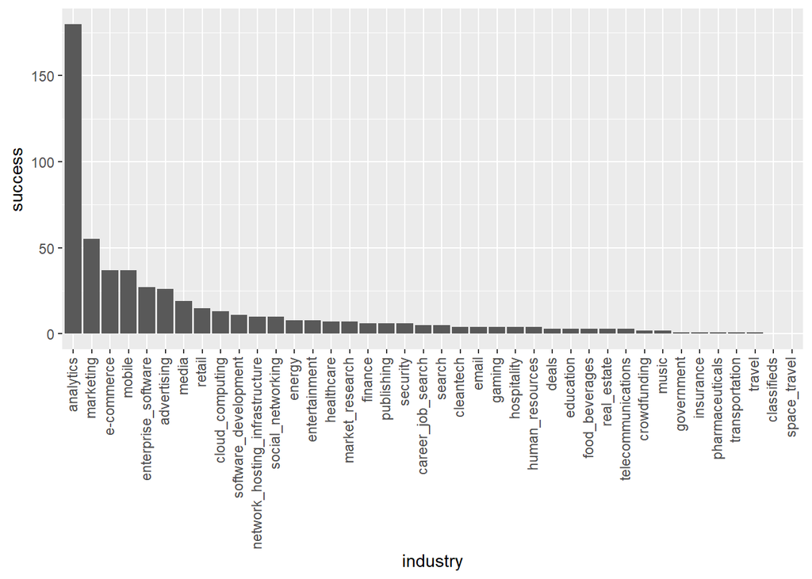

```r
# visualize number of successful companies per industry
industry_frequencies %>%
  transform(industry=reorder(industry, -success) ) %>%        # order x-axis labels by '-success'
  ggplot(aes(x = industry, y = success)) +                    # X: industry, Y: #successful companies
  geom_bar(stat="identity") +                                 #
  theme(axis.text.x = element_text(angle = 90,                # rotate orientation of x-axis labels
                                   vjust = 0.3,               # top-align x-axis labels
                                   hjust = 1))                # right-align x-axis labels
```

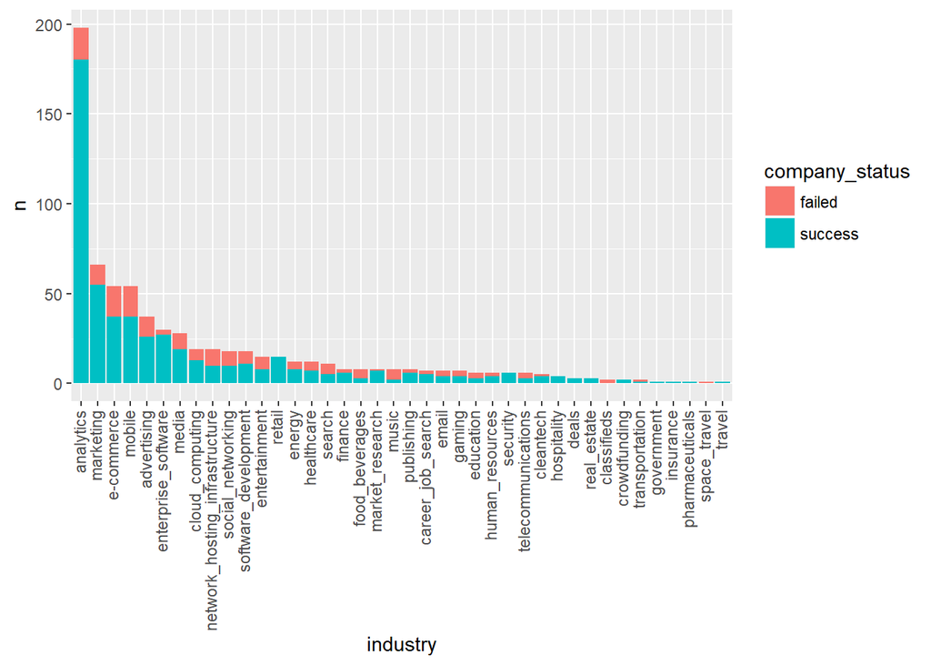

```r
# visualize number of successful/failed companies per industry
industry_frequencies %>%
  gather("company_status", "n", 2:3) %>%
  transform(industry=reorder(industry, -n) ) %>%              # order x-axis labels by '-success'
  ggplot(aes(x = industry, y = n, fill = company_status)) +   # X: industry, Y: n, fill: company_status
  geom_bar(stat="identity") +                                 #
  theme(axis.text.x = element_text(angle = 90,                # rotate orientation of x-axis labels
                                   vjust = 0.3,               # top-align x-axis labels
                                   hjust = 1))                # right-align x-axis labels
```

From the figure, it seems that most startups actually succeed regardless of the industry. Why don’t we get some exact numbers? Below, we will create a new variable called `success_percent` which displays the percentage of successful companies per industry.

```r
# view industries arranged by percentage of successful companies per industry
industry_frequencies %>%
  mutate(success_percent = round(success / (success+failed) * 100, 1)) %>%
  arrange(desc(success_percent), desc(success))
```

```
## # A tibble: 40 x 4
##    industry        failed success success_percent
##    <chr>            <dbl>   <dbl>           <dbl>
##  1 retail               0   15.0              100
##  2 security             0    6.00             100
##  3 hospitality          0    4.00             100
##  4 deals                0    3.00             100
##  5 real_estate          0    3.00             100
##  6 crowdfunding         0    2.00             100
##  7 government           0    1.00             100
##  8 insurance            0    1.00             100
##  9 pharmaceuticals      0    1.00             100
## 10 travel               0    1.00             100
## # ... with 30 more rows
```

Ahem… I want to see the ENTIRE thing, please?

```r
# view industries arranged by percentage of successful companies per industry
industry_frequencies %>%
  mutate(success_percent = round(success / (success+failed) * 100, 1)) %>%
  arrange(desc(success_percent), desc(success)) %>%
  as.data.frame()   # override dplyr's tibble output
```

```
##                          industry failed success success_percent
## 1                          retail      0      15           100.0
## 2                        security      0       6           100.0
## 3                     hospitality      0       4           100.0
## 4                           deals      0       3           100.0
## 5                     real_estate      0       3           100.0
## 6                    crowdfunding      0       2           100.0
## 7                      government      0       1           100.0
## 8                       insurance      0       1           100.0
## 9                 pharmaceuticals      0       1           100.0
## 10                         travel      0       1           100.0
## 11                      analytics     18     180            90.9
## 12            enterprise_software      3      27            90.0
## 13                market_research      1       7            87.5
## 14                      marketing     11      55            83.3
```

[output cut: 26 more lines]

All endeavors in `retail`, `security` and `hospitality` seem to have ended in success. There are other industries that have flawlessly succeeded as well, but the number of successes are not big enough to be significant.

For the industries with success ratios < 100%, `analytics` seems to be wildly successful with a ~91% success ratio, followed by `enterprise_software`, `marketing` and `advertising`, all with success ratios > 70%. There are still other industries with success ratios > 70%, but (again) the number of companies in these industries are not big enough for the percentages to be significant.

On the other side of the spectrum, there exist industries that are wildly UNsuccessful such as `space_travel` and `classifieds`. Although the numbers of companies are not significant enough to draw conclusions, we don’t need numbers to tell us that `space_travel` is a tough business to get into :). Other industries with more fails than successes are `music`, `food_beverages` and `search`.

Industries in the *hit-or-miss* region (~50% success ratio) include `entertainment`, `network_hosting_infrastructure`, `education` and `telecommunications`. Again, other industries within this *hit-or-miss* region do not have a significantly large number of companies to constitute a trend and, as such, will be ignored.

Below, we take another quick look at the industries containing the bigger numbers of successful companies.

```r
# view industries arranged by percentage of successful companies per industry
industry_frequencies %>%
  mutate(success_percent = round(success / (success+failed) * 100, 1)) %>%
  arrange(desc(success), desc(success_percent))
```

```
## # A tibble: 40 x 4
##    industry             failed success success_percent
##    <chr>                 <dbl>   <dbl>           <dbl>
##  1 analytics             18.0    180              90.9
##  2 marketing             11.0     55.0            83.3
##  3 e-commerce            17.0     37.0            68.5
##  4 mobile                17.0     37.0            68.5
##  5 enterprise_software    3.00    27.0            90.0
##  6 advertising           11.0     26.0            70.3
##  7 media                  9.00    19.0            67.9
##  8 retail                 0       15.0           100
##  9 cloud_computing        6.00    13.0            68.4
## 10 software_development   7.00    11.0            61.1
## # ... with 30 more rows
```

We realize that while not all of the above 10 industrues contain superb success percentages, they are all > 60%.

Now, let’s have a look at one of the industries (as an example), particularly its failed companies. We shall observe the `analytics` industry.

```r
analytic_startups_failed <-
  startups_industry %>%
  filter(analytics == 1, `dependent-company_status` == 'FAILED') %>%
  select(-c(`dependent-company_status`, `analytics`))   # don't need these columns anymore

analytic_startups_failed[,colSums(analytic_startups_failed) > 0] %>%
  colSums() %>%
  sort() %>%
  t() %>% t()
```

```
##                                [,1]
## cloud_computing                   1
## mobile                            1
## enterprise_software               1
## food_beverages                    1
## finance                           1
## human_resources                   1
## career_job_search                 1
## education                         1
## energy                            1
## network_hosting_infrastructure    2
## healthcare                        2
## e-commerce                        2
## marketing                         3
## software_development              3
## advertising                       3
## social_networking                 3
```

Nothing particularly interesting here. Let’s try the same thing, but with the successful companies of the `analytics` industry.

```r
analytic_startups_success <-
  startups_industry %>%
  filter(analytics == 1, `dependent-company_status` == 'SUCCESS') %>%
  select(-c(`dependent-company_status`, `analytics`))   # don't need these columns anymore

analytic_startups_success[,colSums(analytic_startups_success) > 0] %>%
  colSums() %>%
  sort() %>%
  t() %>% t()
```

```
##                                [,1]
## crowdfunding                      1
## pharmaceuticals                   1
## education                         1
## transportation                    1
## real_estate                       1
## insurance                         1
## travel                            1
## government                        1
## food_beverages                    2
## music                             2
## gaming                            2
## human_resources                   2
## career_job_search                 2
## deals                             2
## telecommunications                2
## cleantech                         2
## market_research                   3
## hospitality                       3
## healthcare                        3
## finance                           3
## security                          3
## email                             3
## publishing                        3
## energy                            3
## search                            4
## cloud_computing                   7
## network_hosting_infrastructure    7
## retail                            7
## entertainment                     7
## software_development              8
## social_networking                 8
## media                            14
## advertising                      19
## enterprise_software              20
## e-commerce                       24
## mobile                           25
## marketing                        38
```

The hot industries in `analytics` seems to be the `marketing`, `mobile`, `e-commerce`, `enterprise_software` and `advertising` industries. Let’s do some SUCCESS/FAILED comparison.

```r
# summarize the industries within 'analytics'
analytic_startups_summary <- t(rbind(colSums(analytic_startups_failed), colSums(analytic_startups_success)))

# modify column names
colnames(analytic_startups_summary) <- c('failed','success')

analytic_startups_summary[order(-analytic_startups_summary[,2]),]
```

```
##                                failed success
## marketing                           3      38
## mobile                              1      25
## e-commerce                          2      24
## enterprise_software                 1      20
## advertising                         3      19
## media                               0      14
## software_development                3       8
## social_networking                   3       8
## cloud_computing                     1       7
## network_hosting_infrastructure      2       7
## retail                              0       7
## entertainment                       0       7
## search                              0       4
## market_research                     0       3
## hospitality                         0       3
## healthcare                          2       3
## finance                             1       3
## security                            0       3
## email                               0       3
## publishing                          0       3
## energy                              1       3
## food_beverages                      1       2
## music                               0       2
## gaming                              0       2
## human_resources                     1       2
## career_job_search                   1       2
## deals                               0       2
## telecommunications                  0       2
## cleantech                           0       2
## crowdfunding                        0       1
## pharmaceuticals                     0       1
## education                           1       1
## transportation                      0       1
## real_estate                         0       1
## insurance                           0       1
## travel                              0       1
## government                          0       1
## space_travel                        0       0
## classifieds                         0       0
```

The above output would look more interesting visualized.

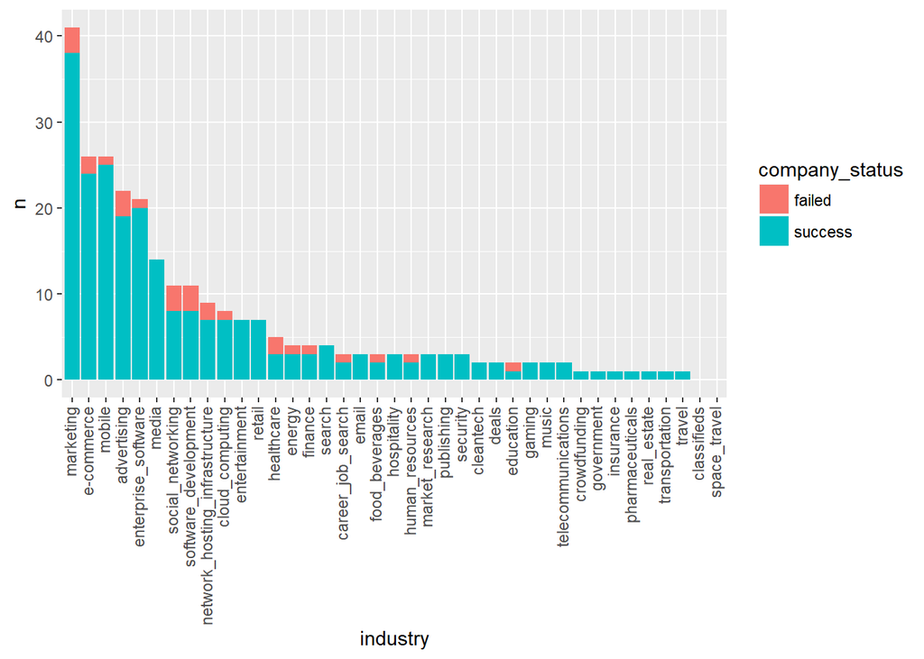

```r
# add the industries (currently the row names) as a column in 'analytic_startups_summary'
analytic_startups_summary <- cbind(rownames(analytic_startups_summary), analytic_startups_summary)

# remove the row names
rownames(analytic_startups_summary) <- NULL

# set the column names
colnames(analytic_startups_summary) <- c('industry','failed','success')

# convert to data frame
analytic_startups_summary <- as.data.frame(analytic_startups_summary, stringsAsFactors = FALSE)

# convert the numeric columns to type 'numeric'
analytic_startups_summary[,c("failed","success")] <-
  map_df(analytic_startups_summary[,c("failed","success")], as.numeric)

# visualize number of successful/failed analytics companies per industry
analytic_startups_summary %>%
  gather("company_status", "n", 2:3) %>%
  transform(industry=reorder(industry, -n) ) %>%              # order x-axis labels by '-success'
  ggplot(aes(x = industry, y = n, fill = company_status)) +   # X: industry, Y: n, fill: company_status
  geom_bar(stat="identity") +                                 #
  theme(axis.text.x = element_text(angle = 90,                # rotate orientation of x-axis labels
                                   vjust = 0.3,               # top-align x-axis labels
                                   hjust = 1))                # right-align x-axis labels
```

The [ggplot2](https://cran.r-project.org/web/packages/ggplot2/) prefers the data be in a *tidy* format (all variables in columns, all observations in rows, all cells containing a single value each). As far as the `ggplot()` function is concerned, it is expecting us to specify a variable (column) as the x-axis and another variable (column) as the y-axis. This is why the industries were added as a column in the data frame (to be later displayed as the x-axis in the visualization). The `dplyr::gather()` function was used to produce a nice-looking visualization of the entire data together (instead of just either the failed or succesful companies alone).

Let’s do the above analysis again but for companies that do NOT have `analytics` as one of its industries.

```r
non_analytic_startups_failed <-
  startups_industry %>%
  filter(analytics == 0, `dependent-company_status` == 'FAILED') %>%
  select(-c(`dependent-company_status`, `analytics`))   # don't need these columns anymore

non_analytic_startups_success <-
  startups_industry %>%
  filter(analytics == 0, `dependent-company_status` == 'SUCCESS') %>%
  select(-c(`dependent-company_status`, `analytics`))   # don't need these columns anymore

# summarize the industries within 'analytics'
non_analytic_startups_summary <- t(rbind(colSums(non_analytic_startups_failed),
                                         colSums(non_analytic_startups_success)))

# modify column names
colnames(non_analytic_startups_summary) <- c('failed','success')

non_analytic_startups_summary[order(-non_analytic_startups_summary[,2]),]
```

```
##                                failed success
## marketing                           8      17
## e-commerce                         15      13
## mobile                             16      12
## retail                              0       8
## enterprise_software                 2       7
## advertising                         8       7
## cloud_computing                     5       6
## media                               9       5
## energy                              3       5
## market_research                     1       4
## healthcare                          3       4
## software_development                4       3
## network_hosting_infrastructure      7       3
## finance                             1       3
## security                            0       3
## career_job_search                   1       3
## publishing                          2       3
## gaming                              3       2
## human_resources                     1       2
## education                           2       2
## social_networking                   5       2
## real_estate                         0       2
## cleantech                           1       2
## crowdfunding                        0       1
## food_beverages                      4       1
## hospitality                         0       1
## email                               3       1
## deals                               0       1
## entertainment                       7       1
## search                              6       1
## telecommunications                  3       1
## pharmaceuticals                     0       0
## music                               6       0
## transportation                      1       0
## insurance                           0       0
## space_travel                        1       0
## classifieds                         2       0
## travel                              0       0
## government                          0       0
```

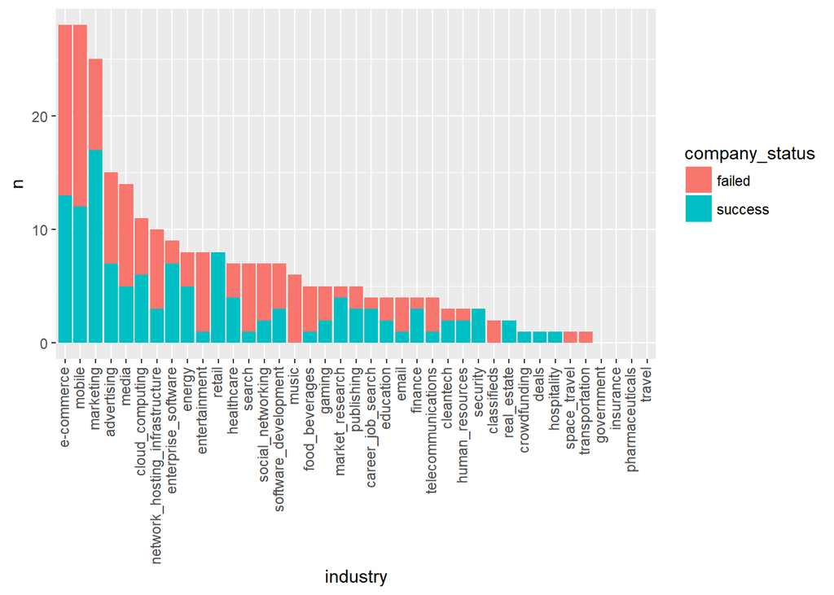

```r
# add the industries (currently the row names) as a column in 'analytic_startups_summary'
non_analytic_startups_summary <- cbind(rownames(non_analytic_startups_summary), non_analytic_startups_summary)

# remove the row names
rownames(non_analytic_startups_summary) <- NULL

# set the column names
colnames(non_analytic_startups_summary) <- c('industry','failed','success')

# convert to data frame
non_analytic_startups_summary <- as.data.frame(non_analytic_startups_summary, stringsAsFactors = FALSE)

# convert the numeric columns to type 'numeric'
non_analytic_startups_summary[,c("failed","success")] <-
  map_df(non_analytic_startups_summary[,c("failed","success")], as.numeric)

# visualize number of successful/failed non-analytics companies per industry
non_analytic_startups_summary %>%
  gather("company_status", "n", 2:3) %>%
  transform(industry=reorder(industry, -n) ) %>%              # order x-axis labels by '-success'
  ggplot(aes(x = industry, y = n, fill = company_status)) +   # X: industry, Y: n, fill: company_status
  geom_bar(stat="identity") +                                 #
  theme(axis.text.x = element_text(angle = 90,                # rotate orientation of x-axis labels
                                   vjust = 0.3,               # top-align x-axis labels
                                   hjust = 1))                # right-align x-axis labels
```

An interesting result, indeed! It seems that companies that adopt analytics capabilities have a much larger chance of success.

```r
library(gridExtra)
```

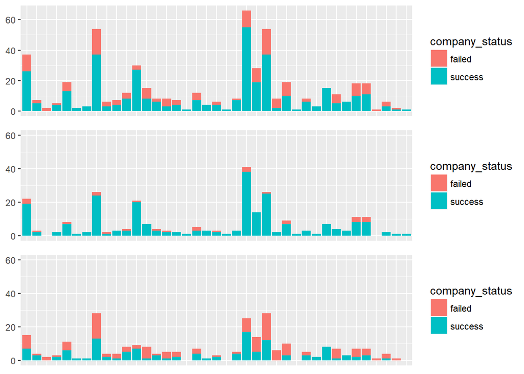

```r
top_plot <-
  industry_frequencies %>%
  filter(industry != "analytics") %>%                         # ignore the 'analytics' industry
  gather("company_status", "n", 2:3) %>%
  ggplot(aes(x = industry, y = n, fill = company_status)) +   # X: industry, Y: n, fill: company_status
  geom_bar(stat="identity") +                                 #
  theme(axis.title.x = element_blank(),                       # blanking out x-axis labels so
        axis.text.x = element_blank(),                        # ...visualizations would fit on
        axis.ticks.x = element_blank(),                       # ...top of each other
        axis.title.y = element_blank())                       # blanking out y-axis labels so

middle_plot <-
  analytic_startups_summary %>%
  gather("company_status", "n", 2:3) %>%
  ggplot(aes(x = industry, y = n, fill = company_status)) +   # X: industry, Y: n, fill: company_status
  geom_bar(stat="identity") +                                 #
  scale_y_continuous(limits = c(0,60)) +                      # fix limits for y-scale
  theme(axis.title.x = element_blank(),                       # blanking out x-axis labels so
        axis.text.x = element_blank(),                        # ...visualizations would fit on
        axis.ticks.x = element_blank(),                       # ...top of each other
        axis.title.y = element_blank())                       # blanking out y-axis labels so

bottom_plot <-
  non_analytic_startups_summary %>%
  gather("company_status", "n", 2:3) %>%
  ggplot(aes(x = industry, y = n, fill = company_status)) +   # X: industry, Y: n, fill: company_status
  geom_bar(stat="identity") +                                 #
  ylim(0,60) +                                                # fix limits for y-scale
  theme(axis.title.x = element_blank(),                       # blanking out x-axis labels so
        axis.text.x = element_blank(),                        # ...visualizations would fit on
        axis.ticks.x = element_blank(),                       # ...top of each other
        axis.title.y = element_blank())                       # blanking out y-axis labels so

grid.arrange(top_plot, middle_plot, bottom_plot, ncol=1)
```

The above figure confirms what we already know about the data so far, and that is: `analytics` dramatically increases the chances that a startup will ultimately succeed.

```r
# alphabetically sorts the list of industries for each company
industrySorter<- function(industries) {
  if(is.na(industries)) {
    industries <- ""
  }
  else {
    industries <-                 # e.g. "gaming entertainment mobile"
      industries %>%              #
      strsplit(" ") %>%           # "gaming" "entertainment" "mobile"
      unlist() %>%                #
      sort() %>%                  # "entertainment" "gaming" "mobile"
      tokens() %>%
      tokens_wordstem() %>%       # "entertain" "game" "mobil"
      paste(collapse = " ")       # "entertain game mobil"
  }
  return(industries)
}
startups$industry_of_company <- map_chr(startups$industry_of_company, industrySorter)

startups$industry_of_company %>%
  head(10)
```

```
##  [1] ""
##  [2] "crowdfund market_research market"
##  [3] "analyt cloud_comput software_develop"
##  [4] "analyt mobil"
##  [5] "analyt enterprise_softwar market"
##  [6] "food_beverag hospit"
##  [7] "analyt"
##  [8] "cloud_comput network_hosting_infrastructur"
##  [9] "analyt market mobil"
## [10] "analyt healthcar pharmaceut"
```

```r
# show all the industry combinations in the data and the number of companies in each
startups%>%
  group_by(industry_of_company) %>%
  summarise(companies = n()) %>%
  arrange(industry_of_company)       # sort industries alphabetically
```

```
## # A tibble: 174 x 2
##    industry_of_company                                           companies
##    <chr>                                                             <int>
##  1 ""                                                                  124
##  2 advertis                                                              4
##  3 advertis analyt                                                       5
##  4 advertis analyt cloud_comput market                                   1
##  5 advertis analyt e-commerc                                             1
##  6 advertis analyt e-commerc enterprise_softwar                          1
##  7 advertis analyt e-commerc enterprise_softwar market mobil so~         1
##  8 advertis analyt e-commerc market                                      1
##  9 advertis analyt e-commerc market mobil                                1
## 10 advertis analyt e-commerc mobil                                       1
## # ... with 164 more rows
```

```r
# show all the industry combinations in the data and the number of companies in each
startups%>%
  group_by(industry_of_company) %>%
  summarise(companies = n()) %>%
  arrange(desc(companies))       # sort industries by number of companies
```

```
## # A tibble: 174 x 2
##    industry_of_company       companies
##    <chr>                         <int>
##  1 ""                              124
##  2 analyt                           53
##  3 analyt market                    17
##  4 e-commerc                         9
##  5 analyt e-commerc                  8
##  6 market                            8
##  7 analyt enterprise_softwar         7
##  8 analyt mobil                      7
##  9 advertis analyt                   5
## 10 mobil                             5
## # ... with 164 more rows
```

Let’s try doing something more useful.

```r
# show all the industry combinations in the data and the number of failed/successful companies in each
startups%>%
  group_by(industry_of_company, `dependent-company_status`) %>%
  summarise(companies = n()) %>%
  arrange(desc(companies))       # sort industries by number of companies
```

```
## # A tibble: 199 x 3
## # Groups:   industry_of_company [174]
##    industry_of_company       `dependent-company_status` companies
##    <chr>                     <fct>                          <int>
##  1 ""                        FAILED                            69
##  2 ""                        SUCCESS                           55
##  3 analyt                    SUCCESS                           52
##  4 analyt market             SUCCESS                           16
##  5 analyt e-commerc          SUCCESS                            7
##  6 analyt mobil              SUCCESS                            7
##  7 e-commerc                 FAILED                             7
##  8 market                    SUCCESS                            7
##  9 analyt enterprise_softwar SUCCESS                            6
## 10 mobil                     FAILED                             5
## # ... with 189 more rows
```

Let’s convert the above data into a *tidy* format.

```r
# show all the industry combinations in the data and the number of failed/successful companies in each
startups%>%
  group_by(industry_of_company, `dependent-company_status`) %>%
  summarise(companies = n()) %>%
  spread(`dependent-company_status`, companies) %>%
  arrange(desc(SUCCESS))       # sort industries by number of successful companies
```

```
## # A tibble: 174 x 3
## # Groups:   industry_of_company [174]
##    industry_of_company            FAILED SUCCESS
##    <chr>                           <int>   <int>
##  1 ""                                 69      55
##  2 analyt                              1      52
##  3 analyt market                       1      16
##  4 analyt e-commerc                    1       7
##  5 analyt mobil                       NA       7
##  6 market                              1       7
##  7 analyt enterprise_softwar           1       6
##  8 enterprise_softwar                 NA       4
##  9 advertis analyt                     2       3
## 10 analyt market software_develop     NA       3
## # ... with 164 more rows
```

Let’s remove the first row (corresponding to the `NA` industry) and replace the NA’s within the table with 0’s.

```r
my_summarised_startups_industry <-
  startups%>%
  group_by(industry_of_company, `dependent-company_status`) %>%
  summarise(companies = n()) %>%
  spread(`dependent-company_status`, companies) %>%
  filter(industry_of_company != "") %>%
  arrange(desc(SUCCESS))       # sort industries by number of successful companies

# replace the NA's with 0's
my_summarised_startups_industry[is.na(my_summarised_startups_industry)] <- 0

my_summarised_startups_industry
```

```
## # A tibble: 173 x 3
## # Groups:   industry_of_company [173]
##    industry_of_company            FAILED SUCCESS
##    <chr>                           <dbl>   <dbl>
##  1 analyt                           1.00   52.0
##  2 analyt market                    1.00   16.0
##  3 analyt e-commerc                 1.00    7.00
##  4 analyt mobil                     0       7.00
##  5 market                           1.00    7.00
##  6 analyt enterprise_softwar        1.00    6.00
##  7 enterprise_softwar               0       4.00
##  8 advertis analyt                  2.00    3.00
##  9 analyt market software_develop   0       3.00
## 10 healthcar                        1.00    3.00
## # ... with 163 more rows
```

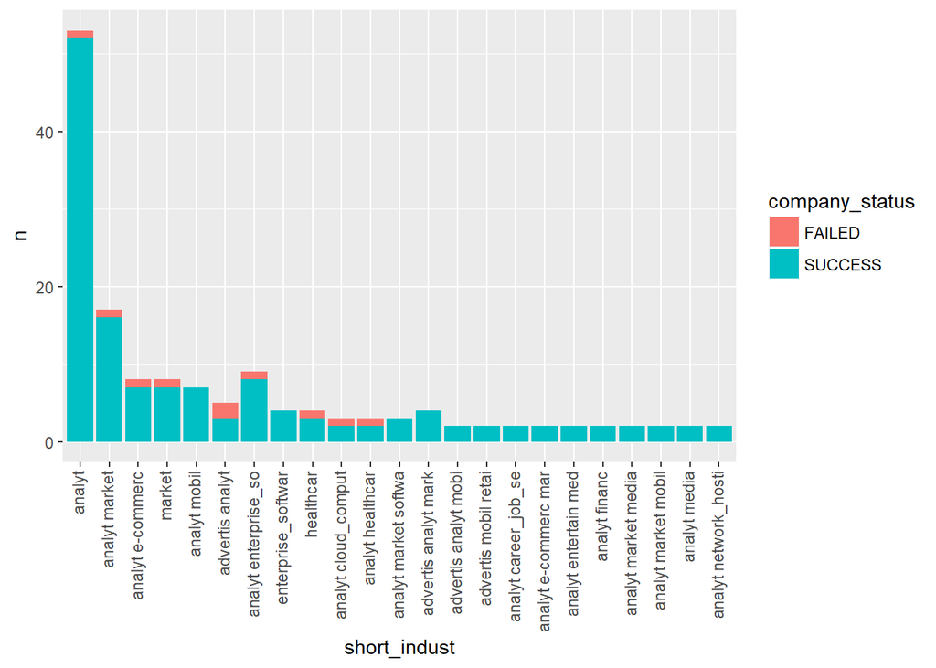

```r
my_summarised_startups_industry %>%
  head(25) %>%
  gather("company_status","n",2:3) %>%
  mutate(short_indust = strtrim(industry_of_company, 20)) %>%
  transform(short_indust=reorder(short_indust, -n) ) %>%      # order x-axis labels by '-n'
  ggplot(aes(x=short_indust, y=n, fill=company_status)) +     # X: industry, Y: #successful companies
  geom_bar(stat="identity") +                                 #
  theme(axis.text.x = element_text(angle = 90,                # rotate orientation of x-axis labels
                                   vjust = 0.3,               # top-align x-axis labels
                                   hjust = 1))                # right-align x-axis labels
```

Now, let’s show the industry combinations with the highest fail rates.

```r
my_summarised_startups_industry <-
  my_summarised_startups_industry %>%
  arrange(desc(FAILED))

my_summarised_startups_industry
```

```
## # A tibble: 173 x 3
## # Groups:   industry_of_company [173]
##    industry_of_company     FAILED SUCCESS
##    <chr>                    <dbl>   <dbl>
##  1 e-commerc                 7.00    2.00
##  2 mobil                     5.00    0
##  3 advertis                  3.00    1.00
##  4 analyt software_develop   3.00    0
##  5 media                     3.00    0
##  6 music                     3.00    0
##  7 search                    3.00    0
##  8 advertis analyt           2.00    3.00
##  9 software_develop          2.00    2.00
## 10 cloud_comput              2.00    1.00
## # ... with 163 more rows
```

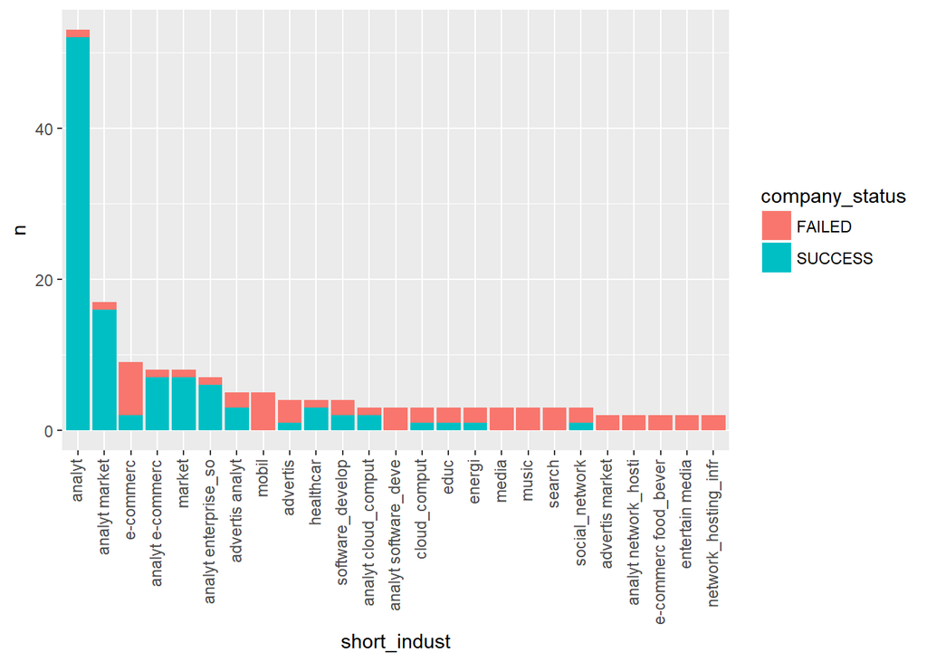

```r
my_summarised_startups_industry %>%
  head(25) %>%
  gather("company_status","n",2:3) %>%
  mutate(short_indust = strtrim(industry_of_company, 20)) %>%
  transform(short_indust=reorder(short_indust, -n) ) %>%      # order x-axis labels by '-n'
  ggplot(aes(x=short_indust, y=n, fill=company_status)) +     # X: industry, Y: #successful companies
  geom_bar(stat="identity") +                                 #
  theme(axis.text.x = element_text(angle = 90,                # rotate orientation of x-axis labels
                                   vjust = 0.3,               # top-align x-axis labels
                                   hjust = 1))                # right-align x-axis labels
```

Let’s have a look at the effect of the company founding date on the chance of success. It may be the case that startups were still getting the hang of it in earlier days and, as time went by, a bunch of common mistakes done by the earlier startups were avoided by the following ones. We will repeat this analysis twice, once for all companies in general and another time for companies that have `analytics` as one of its industries.

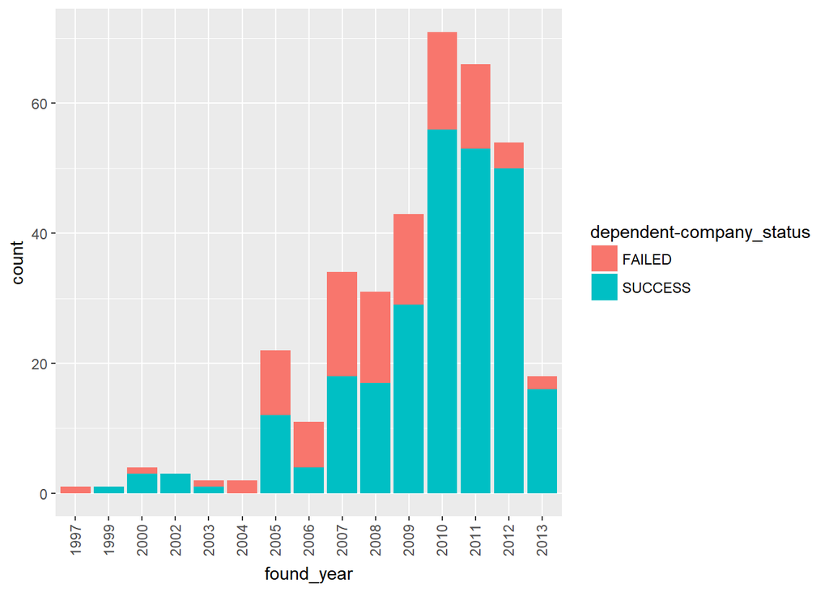

```r
startups %>%
  separate(est._founding_date,c("found_year","found_month","found_day"),"-") %>%
  filter(!is.na(found_year)) %>%
  select(found_year, `dependent-company_status`) %>%
  ggplot(aes(x = found_year, fill = `dependent-company_status`)) +
  geom_histogram(stat="count") +
  theme(axis.text.x = element_text(angle = 90,                # rotate orientation of x-axis labels
                                   vjust = 0.4,               # top-align x-axis labels
                                   hjust = 1))                # right-align x-axis labels
```

A quick look at the above figure shows that the percentage of successful companies has increased in the last five years. Let’s see it in numbers.

```r
startups %>%
  separate(est._founding_date,c("found_year","found_month","found_day"),"-") %>%
  filter(!is.na(found_year)) %>%
  select(found_year,`dependent-company_status`) %>%
  group_by(found_year,`dependent-company_status`) %>%
  summarise(count = n()) %>%
  spread(`dependent-company_status`, count) %>%
  replace_na(list(FAILED = 0, SUCCESS = 0)) %>%                # replace NA's with 0's
  mutate(success_percent = SUCCESS / (SUCCESS + FAILED)) %>%   # create success_percent variable
  arrange(desc(success_percent))                               # sort descendingly by success_percent
```

```
## # A tibble: 15 x 4
## # Groups:   found_year [15]
##    found_year FAILED SUCCESS success_percent
##    <chr>       <dbl>   <dbl>           <dbl>
##  1 1999         0       1.00           1.00
##  2 2002         0       3.00           1.00
##  3 2012         4.00   50.0            0.926
##  4 2013         2.00   16.0            0.889
##  5 2011        13.0    53.0            0.803
##  6 2010        15.0    56.0            0.789
##  7 2000         1.00    3.00           0.750
##  8 2009        14.0    29.0            0.674
##  9 2008        14.0    17.0            0.548
## 10 2005        10.0    12.0            0.545
## 11 2007        16.0    18.0            0.529
## 12 2003         1.00    1.00           0.500
## 13 2006         7.00    4.00           0.364
## 14 1997         1.00    0              0
## 15 2004         2.00    0              0
```

From the above output, it is clear that the higher success percentages are more towards recent years. The first two rows, (i.e. years 1999 and 2002) have too few companies for their success percentages to be significant, so we’ll pretend they are not there.

Now, let’s repeat the above couple of steps for `analytics`-inclined companies and see if we get similar observations.

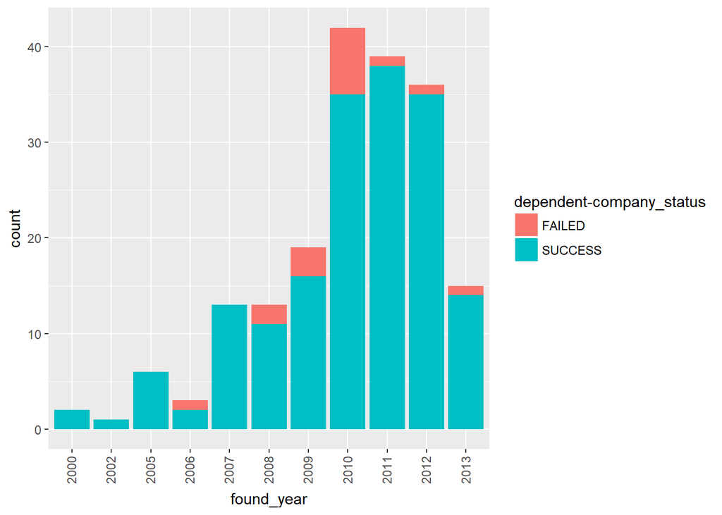

```r
startups %>%
  separate(est._founding_date,c("found_year","found_month","found_day"),"-") %>%
  filter(!is.na(found_year) & grepl("analyt", industry_of_company)) %>%  # analytics companies only
  select(found_year, `dependent-company_status`) %>%
  ggplot(aes(x = found_year, fill = `dependent-company_status`)) +
  geom_histogram(stat="count") +
  theme(axis.text.x = element_text(angle = 90,                # rotate orientation of x-axis labels
                                   vjust = 0.4,               # top-align x-axis labels
                                   hjust = 1))                # right-align x-axis labels
```

```r
startups %>%
  separate(est._founding_date,c("found_year","found_month","found_day"),"-") %>%
  filter(!is.na(found_year) & grepl("analyt", industry_of_company)) %>%  # analytics companies only
  select(found_year,`dependent-company_status`) %>%
  group_by(found_year,`dependent-company_status`) %>%
  summarise(count = n()) %>%
  spread(`dependent-company_status`, count) %>%
  replace_na(list(FAILED = 0, SUCCESS = 0)) %>%                # replace NA's with 0's
  mutate(success_percent = SUCCESS / (SUCCESS + FAILED)) %>%   # create success_percent variable
  arrange(desc(success_percent))                               # sort descendingly by success_percent
```

```
## # A tibble: 11 x 4
## # Groups:   found_year [11]
##    found_year FAILED SUCCESS success_percent
##    <chr>       <dbl>   <dbl>           <dbl>
##  1 2000         0       2.00           1.00
##  2 2002         0       1.00           1.00
##  3 2005         0       6.00           1.00
##  4 2007         0      13.0            1.00
##  5 2011         1.00   38.0            0.974
##  6 2012         1.00   35.0            0.972
##  7 2013         1.00   14.0            0.933
##  8 2008         2.00   11.0            0.846
##  9 2009         3.00   16.0            0.842
## 10 2010         7.00   35.0            0.833
## 11 2006         1.00    2.00           0.667
```

From the above figure and results, `analytics` seems to have higher success percentages than those seen for all companies regardless of industry. The lowest osberved success percentage for `analytics` companies was observed in 2006. However, there were only 3 startups in 2006. For the rest of the years, the success percentages were generally quite high (> 80%). Again, these higher percentages are more meaningful for the recent years that have seen more startups.

*To be continued…*

#### Short description of company profile

Until now I do not know what to do with it

```r
head(startups$short_description_of_company_profile, 10)
```

```
##  [1] "video distribution"
##  [2] NA
##  [3] "event data analytics api"
##  [4] "the most advanced analytics for mobile"
##  [5] "the location-based marketing platform"
##  [6] "big data for foodservice"
##  [7] NA
##  [8] NA
##  [9] "engagement engine"
## [10] "big data for clinical insight"
```

The NA’s will probably cause problems at the DTM generation step later, so let’s remove them.

```r
# eliminate NA's
startups$short_description_of_company_profile[is.na(startups$short_description_of_company_profile)] <- ''

head(startups$short_description_of_company_profile, 10)
```

```
##  [1] "video distribution"
##  [2] ""
##  [3] "event data analytics api"
##  [4] "the most advanced analytics for mobile"
##  [5] "the location-based marketing platform"
##  [6] "big data for foodservice"
##  [7] ""
##  [8] ""
##  [9] "engagement engine"
## [10] "big data for clinical insight"
```

Let’s carry on and generate the DTM matrix.

```r
# create the corpus object from the short_description_of_company_profile column
mycorpus <- corpus(startups$short_description_of_company_profile)

# list of stop words
my_stopwords <- stopwords('english')

# generate the DTM using the formed corpus
dfm_desc <- dfm(mycorpus,               # the corpus to generate the DTM from
                remove_punct = TRUE,    # remove punctuation
                remove_symbols = TRUE,  # remove symbols
                remove = my_stopwords,  # remove stopwords
                tolower = FALSE)        # data is already lowercase
```

Like before, let’s have a look at the DTM before moving on.

```r
# observe the 'terms' of the DTM
colnames(dfm_desc)
```

```
##   [1] "video"                 "distribution"
##   [3] "event"                 "data"
##   [5] "analytics"             "api"
##   [7] "advanced"              "mobile"
##   [9] "location-based"        "marketing"
##  [11] "platform"              "big"
##  [13] "foodservice"           "engagement"
##  [15] "engine"                "clinical"
##  [17] "insight"               "business"
##  [19] "human"                 "machine"
##  [21] "scale"                 "music"
##  [23] "industry"              "predictive"
##  [25] "healthcare"            "intelligence"
##  [27] "water"                 "management"
##  [29] "solutions"             "in-store"
```

[output cut: 217 more lines]

This resulted in 463 distinct terms. Let’s see if we can shrink that number further by stemming. There are a few terms that end in *’s* that we will deal with as well. By the way, we see the `ﬁnancial` term, but we are just ignoring it for now.

```r
# remove the 's
startups$short_description_of_company_profile <-
  gsub(x = startups$short_description_of_company_profile, pattern = '\'s', replacement = '')

# create the corpus object from the short_description_of_company_profile column
mycorpus <- corpus(startups$short_description_of_company_profile)

# list of stop words
my_stopwords <- stopwords('english')

# generate the DTM using the formed corpus
dfm_desc <- dfm(mycorpus,               # the corpus to generate the DTM from
                remove_punct = TRUE,    # remove punctuation
                remove_symbols = TRUE,  # remove symbols
                remove = my_stopwords,  # remove stopwords
                tolower = FALSE)        # data is already lowercase

# stem the terms of the dfm
dfm_desc <- dfm_wordstem(dfm_desc)

# observe the 'terms' of the DTM
dim(dfm_desc)
```

```
## [1] 472 412
```

We manged to shrink the number of terms from 463 to 412 terms. We noticed that there are terms containing only a single letter (`r` and `s`). Let’s have a look at some of the records (i.e. companies) that possess these single-lettered terms.

```r
# show the cases having the 'r' term
startups$short_description_of_company_profile[as.logical(dfm_desc[,"r"])]
```

```
## [1] "r language professional support"
```

```r
# show the cases having the 's' term
startups$short_description_of_company_profile[as.logical(dfm_desc[,"s"])]
```

```
## [1] "mailbox web service api s"
```

Okay. The `r` term makes sense, but the `s` does not seem very useful. Let’s remove it.

```r
# remove the 's' term from the DTM
dfm_desc <- dfm_desc[,-which(colnames(dfm_desc)=='s')]

# confirm 's' column was removed
dim(dfm_desc)
```

```
## [1] 472 411
```

Since the number of observations (or records) in this dataset is quite low, we are expecting a lot of the terms in the DTM matrix to have only a single occurrence in the dataset. Let’s see if we are right.

```r
# how many of the terms have single occurrences?
sum(colSums(dfm_desc) == 1)
```

```
## [1] 270
```

```r
# how many of the terms have single occurrences?
sum(colSums(dfm_desc) <= 2)
```

```
## [1] 324
```

Let’s remove these low-frequency terms and analyze the rest.

```r
# remove the low-frequency terms from the DTM
dfm_desc <- dfm_desc[,-which(colSums(dfm_desc) <= 2)]

# check new size of DTM
dim(dfm_desc)
```

```
## [1] 472  87
```

Now, let’s see the number of failed/successful companies (plus percentage of successful companies) for each of the remaining 87 terms.

```r
# convert `dfm_desc` to data.frame and bind with response variable
startups_desc <- cbind(startups[,2], as.data.frame(dfm_desc))

str(startups_desc)
```

```
## 'data.frame':    472 obs. of  88 variables:
##  $ dependent-company_status: Factor w/ 2 levels "FAILED","SUCCESS": 2 2 2 2 2 2 2 2 2 2 ...
##  $ video                   : num  1 0 0 0 0 0 0 0 0 0 ...
##  $ distribut               : num  1 0 0 0 0 0 0 0 0 0 ...
##  $ data                    : num  0 0 1 0 0 1 0 0 0 1 ...
##  $ analyt                  : num  0 0 1 1 0 0 0 0 0 0 ...
##  $ api                     : num  0 0 1 0 0 0 0 0 0 0 ...
##  $ advanc                  : num  0 0 0 1 0 0 0 0 0 0 ...
##  $ mobil                   : num  0 0 0 1 0 0 0 0 0 0 ...
##  $ market                  : num  0 0 0 0 1 0 0 0 0 0 ...
##  $ platform                : num  0 0 0 0 1 0 0 0 0 0 ...
##  $ big                     : num  0 0 0 0 0 1 0 0 0 1 ...
##  $ engag                   : num  0 0 0 0 0 0 0 0 1 0 ...
##  $ engin                   : num  0 0 0 0 0 0 0 0 1 0 ...
##  $ insight                 : num  0 0 0 0 0 0 0 0 0 1 ...
```

[output cut: 74 more lines]

First, let’s have a look at the following histogram.

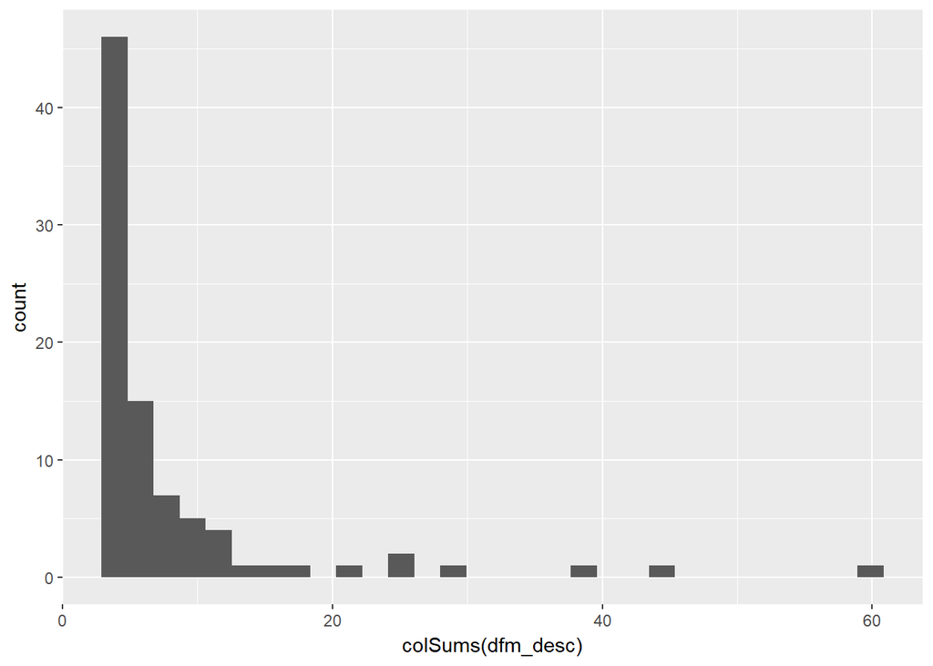

```r
qplot(colSums(dfm_desc), geom="histogram")
```

The majority of the terms are at the low-frequency end, which shouldn’t come as a surprise.

```r
startups_desc%>%
  gather("term","binary",2:88) %>%
  group_by(term) %>%
  summarise(companies = sum(binary == 1)) %>%
  arrange(desc(companies))
```

```
## # A tibble: 87 x 2
##    term     companies
##    <chr>        <int>
##  1 analyt          57
##  2 data            44
##  3 social          39
##  4 market          29
##  5 media           26
##  6 platform        25
##  7 big             21
##  8 custom          17
##  9 mobil           16
## 10 intellig        13
## # ... with 77 more rows
```

Another way to show the above information is to display the number of failed and successful companies per term. We do that below.

```r
startups_desc %>%
  gather("term","binary",2:88) %>%
  group_by(`dependent-company_status`, term) %>%
  summarise(frequency = sum(binary)) %>%
  spread(`dependent-company_status`, frequency) %>%
  mutate(success_percent = SUCCESS/(SUCCESS+FAILED)*100) %>%
  arrange(desc(success_percent),desc(SUCCESS)) %>%
  as.data.frame()
```

```
##         term FAILED SUCCESS success_percent
## 1   intellig      0      13       100.00000
## 2   real-tim      0       9       100.00000
## 3        saa      0       7       100.00000
## 4     system      0       6       100.00000
## 5    insight      0       5       100.00000
## 6     advanc      0       4       100.00000
## 7        api      0       4       100.00000
## 8        app      0       4       100.00000
## 9      autom      0       4       100.00000
## 10    consum      0       4       100.00000
## 11 dashboard      0       4       100.00000
## 12   in-stor      0       4       100.00000
## 13     simpl      0       4       100.00000
## 14    energi      0       3       100.00000
```

[output cut: 73 more lines]

For some reason, the `analyt` companies sum up to 59, while in the previous table, they were 57 companies. Where did the extra two companies come from? This is a mystery that is yet unsolved. Besides that, let’s observe the above table.

For those terms with 100% success rates, we see terms like `intellig`, `real-tim`, `api` and `dashboard`, which are terms that are related to data science and business intelligence. This suggests that startups in such fields are likely to succeed. This is further confirmed by other terms with slightly smaller success rates like `analyt`, `big`, `data` and `predict`. Other terms that have promising success rates as well are `mobil` and `web`.

For terms hovering around the 50% success mark, the strongest examples are `social`, `media` and `market`. We say ‘strongest’ due to the high number of companies involved, which increases our confidence in the observed success rate. For these terms, it seems that there are still lessons to be learned for startups that are considering providing services related to such terms. Other terms that seem to involve risky endeavors are `cloud` and `music`.

Finally, we have a look at terms with very low success rates. It is no surprise that terms like `game` and `payment` are on this list. The gaming industry is very competitive and can be really tough to get into, and a payment-faciltating service that can outperform PayPal would not be easy to pull off. Other terms with low success rates are `email`, `host` and `call` which are all communication-related terms.

Let’s do a few more visualizations before moving on with our analysis.

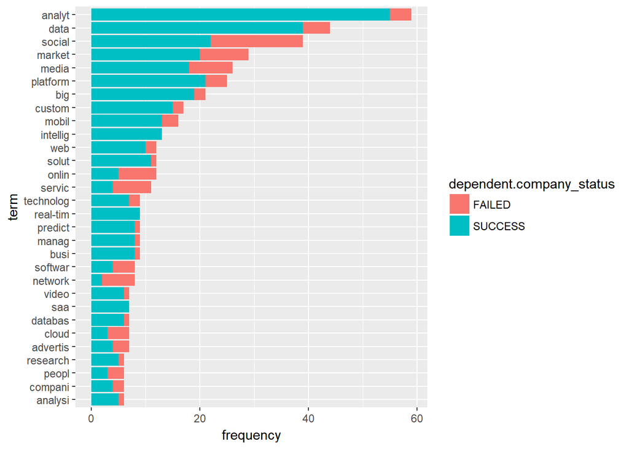

```r
# keep the terms with the highest number of companies
high_freq_terms <-
  startups_desc%>%
  gather("term","binary",2:88) %>%
  group_by(term) %>%
  summarise(companies = sum(binary == 1)) %>%
  arrange(desc(companies)) %>%        # sort terms by number of companies
  head(30) %>%
  select(term) %>%
  unlist()

startups_desc %>%
  gather("term","binary",2:88) %>%
  group_by(`dependent-company_status`, term) %>%
  summarise(frequency = sum(binary)) %>%
  filter(term %in% high_freq_terms) %>%
  arrange(desc(frequency)) %>%
  transform(term=reorder(term, frequency) ) %>%
  ggplot(aes(x = term, y = frequency, fill = `dependent.company_status`)) +
  geom_bar(stat = 'identity') +
  coord_flip()
```

In the figure above, we focus more on the terms with more companies as we have higher confidence in the patterns include within. That is, we excluded the terms that have a fewer number of companies than the `analysi` term.

Based on the figure above, the terms `social`, `onlin`, `servic`, `softwar` and `network` may warrant further investigation due to their unfavorable success rates.

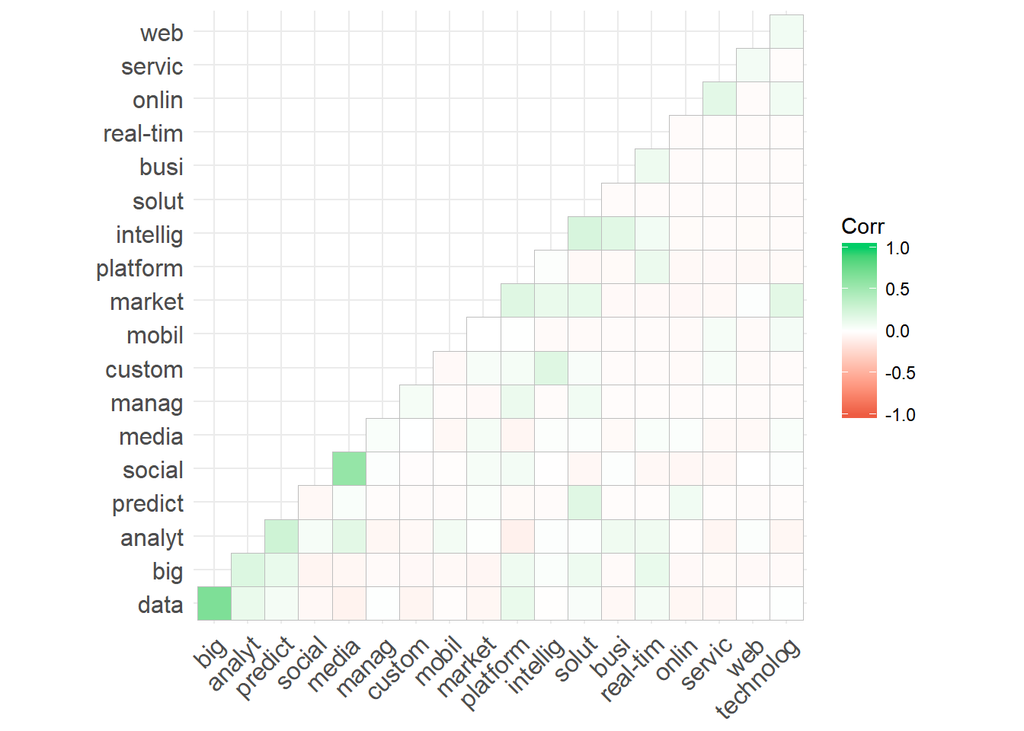

```r
# correlation matrix of the top 10 occurring terms
corr_data <- cor(as.matrix(dfm_desc[,colSums(dfm_desc) %in% tail(sort(colSums(dfm_desc)),15)]))

library(ggcorrplot)
ggcorrplot(corr_data,
           hc.order = TRUE,     # order terms via heirarchical clustering
           type = "lower",
           colors = c("tomato2", "white", "springgreen3"))
```

The two strongest correlating pairs are `big+data` and `social+media`, followed by other pairs such as `analyt+predict`, `predict+solut`, `intellig+solut`, `custom+intellig` and `market+technolog` among others. This correlogram is interesting for uncovering some prevalent trends among startups (e.g. social media and custom intelligence-related solutions). Note that the terms in the figure (which form the labels of the x and y axes) are the most occurring terms in the dataset, meaning that the computed correlations are significant and meaningful.

We end our analysis of the `short_description_of_company_profile` variable here and move on.

#### Focus functions of company

It is a multi-value variable indicate the company foucs.

```r
head(startups$focus_functions_of_company, 10)
```

```
##  [1] "operation"         "marketing, sales"  "operations"
##  [4] "marketing & sales" "marketing & sales" "analytics"
##  [7] "research"          "computing"         "marketing"
## [10] "research"
```

The following are some notes about this field: * values are either seprated by `,` or `&` and sometimes both. * The characters case is not standarized. * Missing functions

#### Investors

It is a multi-value variable. Values are seprated by `|`, and sometimes there are missing values

```r
head(startups$investors, 10)
```

```
##  [1] "kpcb holdings|draper fisher jurvetson (dfj)|kleiner perkins caufield & byers|at&t|blueprint ventures|cisco|zone ventures"
##  [2] NA
##  [3] "techstars|streamlined ventures|amplify partners|rincon venture partners|pelion venture partners|500 startups|loren siebert|jason seats|xg ventures|george karidis|sam choi|morris wheeler|data collective|pejman nozad|ullas naik|dirk elmendorf|galvanize|pat matthews|paul kedrosky|matt ocko|clo…
##  [4] "michael birch|max levchin|sequoia capital|keith rabois|andreessen horowitz|marc benioff|david sacks|y combinator|voyager capital"
##  [5] "dfj frontier|draper nexus ventures|gil elbaz|auren hoffman|walter kortschak|mi ventures|brand ventures|daher capital|double m partners|gold hill capital|clark landry|draper associates|mi ventures llc|signia venture partners"
##  [6] "pritzker group venture capital|excelerate labs|hyde park venture partners|chicago ventures|amicus capital|ideo|olive ventures|kd capital l.l.c"
##  [7] "plug & play ventures|correlation ventures|crosslink capital|roham gharegozlou|start capital|naguib sawiris|pejman nozad|streamlined ventures"
##  [8] "norwest venture partners|bessemer venture partners|atlas venture"
##  [9] "promus ventures|softtech vc|costanoa venture capital|lee linden|chamath palihapitiya|raj de datta|tim kendall|omar siddiqui|david vivero|sequoia capital"
## [10] "khosla ventures"
```

### Time Series Variables

```r
#founding_date <- na.locf(startups$`Est. Founding Date`, na.rm = FALSE)
#startups$`Est. Founding Date` <- na.locf(founding_date, fromLast = TRUE)
#summary(startups$`Est. Founding Date`)

#last_funding_date <- na.locf(startups$`Last Funding Date`, na.rm = FALSE)
#startups$`Last Funding Date` <- na.locf(last_funding_date, fromLast = TRUE)
#summary(startups$`Last Funding Date`)
```

#### EDA

```r
#ggplot(startups, aes(x = `Est. Founding Date`, y = `Dependent-Company Status`)) +
#  geom_point() +
#  scale_x_date('month')  +
#  ylab("Daily Bike Checkouts") +
#  xlab("")
#ggplot(daily_data, aes(Date, cnt)) + geom_line() + scale_x_date('month')  + ylab("Daily Bike Checkouts") +
#            xlab("")
```

# Exploratory Data Analysis

# Feature Engineering

# Pre-Modeling Processing

## Missing Values

## More Exploration

## Hypothesis Testing

## Predictor Selection